# Principios y Prácticas de SEM y MLM (5ed)

Repaso Sesión 2: EFA y selección de análisis

Author

Affiliation

Efraín García Sánchez

CIMCYC — Universidad de Granada

Published

May 22, 2026

# Repaso de la Sesión 2

## Objetivos del repaso

En esta sesión aclaramos tres preguntas prácticas:

1. ¿Cuál es la diferencia entre una **variable latente** y una **dimensión de un constructo**?
2. ¿Cómo se interpreta un **Johnson-Neyman plot** en una interacción?
3. ¿Qué análisis conviene usar según la **pregunta de investigación**?

**Note**

La idea central es conectar la pregunta sustantiva con el modelo estadístico: antes de elegir una técnica, debemos saber qué relación queremos representar.

# Variable Latente vs. Dimensión

## Respuesta corta

**Estadísticamente, no hay una diferencia necesaria.**

Si una dimensión de un constructo se estima a partir de varios indicadores, esa dimensión es también una **variable latente**.

| Término | Qué enfatiza |
| --- | --- |
| **Variable latente** | El estatus estadístico: no se observa directamente, se estima desde indicadores. |
| **Dimensión del constructo** | El estatus conceptual: una parte, faceta o dominio de un constructo más amplio. |

**Important**

La diferencia principal no es estadística, sino **conceptual y teórica**.

## Ejemplo: constructo multidimensional

Supongamos que queremos estudiar **bienestar**.

### Constructo amplio

**Bienestar**

- Concepto general.
- Puede incluir varias facetas.
- No se observa directamente.

### Dimensiones posibles

- **Salud mental**: e.g., satisfacción, felicidad, esperanza, etc.
- **Salud física**: e.g., bmi, actividad física, ausencia de dolor, etc.
- **Conexión social**: e.g., actividades sociales, amigxs, pareja, etc.

Cada dimensión puede ser tratada como una variable latente si se mide con varios indicadores.

## Entonces, ¿qué cambia?

Lo que cambia es el **nivel de abstracción**.

- Una **dimensión** puede ser una variable latente de primer orden.
- Un **constructo general** puede ser una variable latente de segundo orden.
- También podemos usar una sola puntuación observada, pero en ese caso ya no estamos modelando explícitamente el error de medición.

**Note**

En EFA y CFA, cuando hablamos de factores, dimensiones o variables latentes, muchas veces estamos hablando del mismo objeto estadístico: una fuente común de covariación entre indicadores.

## Pregunta útil para decidir

Antes de modelar, conviene preguntarse:

1. ¿El constructo es **unidimensional** o tiene varias dimensiones?
2. ¿Cada dimensión tiene suficientes indicadores?
3. ¿Las dimensiones son conceptualmente distintas?
4. ¿Necesito una puntuación total o factores separados?
5. ¿Estoy explorando la estructura o probando una estructura ya definida?

# Johnson-Neyman

## ¿Qué problema resuelve?

En una moderación, el efecto de **X** sobre **Y** depende del valor de **W**.

El Johnson-Neyman plot responde:

> ¿Para qué valores del moderador **W** el efecto de **X** sobre **Y** es estadísticamente significativo?

No muestra si la interacción global existe; eso se revisa con el término de interacción. El gráfico ayuda a **interpretar dónde ocurre el efecto condicional**.

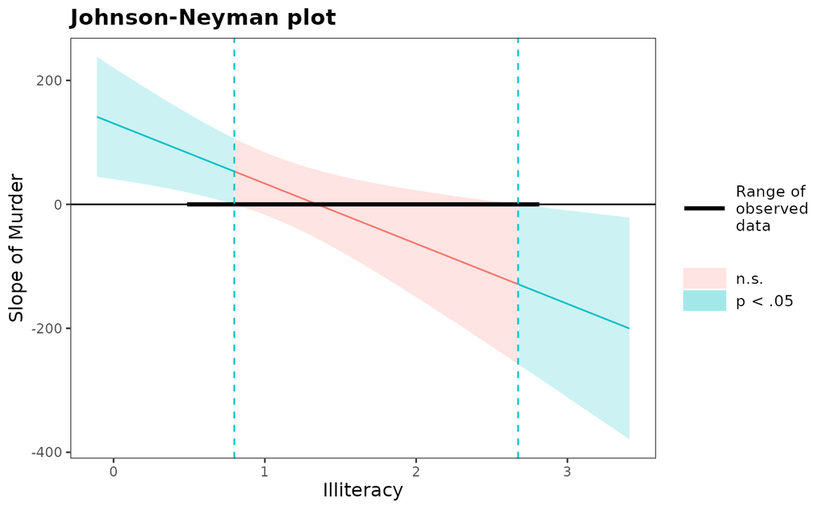

```r
#
fit <- lm(Income ~ HSGrad + Murder*Illiteracy,data = states)
# Murder Rate US States
# Illiteracy in US States
# Income in US States
```

## Cómo leer el gráfico

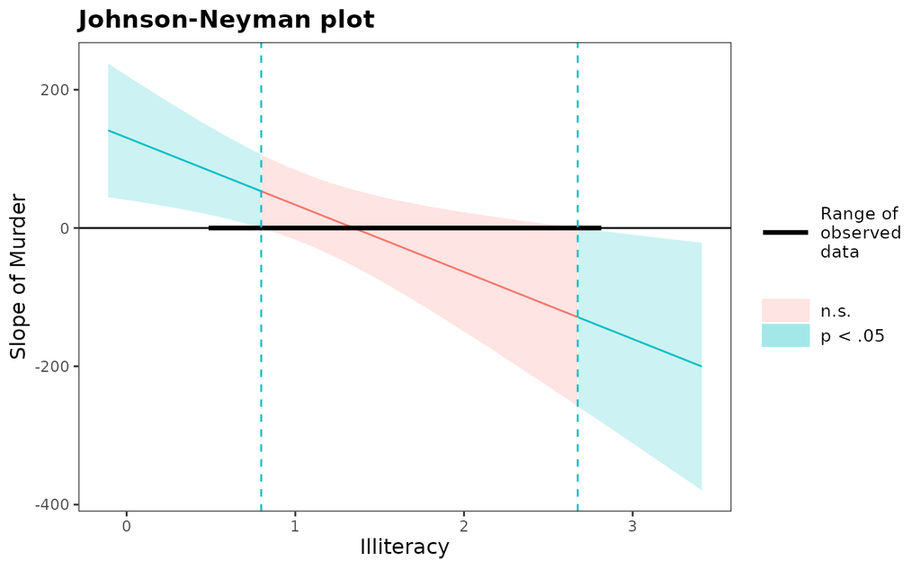

- El eje **X** muestra valores del **moderador**.
- El eje **Y** muestra el **efecto condicional** de la variable focal.
- La línea central es la pendiente estimada.
- Las bandas muestran el intervalo de confianza.
- La región significativa ocurre donde el intervalo de confianza **no cruza cero**.

**Important**

Si el intervalo cruza cero, no tenemos evidencia estadística suficiente para afirmar que el efecto condicional sea distinto de cero en esa región.

## ¿Qué significa una región no significativa?

Una región no significativa significa:

- Para esos valores del moderador, el efecto estimado de **X** sobre **Y** no es suficientemente claro.
- El intervalo de confianza incluye cero.

Esto puede ocurrir porque:

- El efecto es muy pequeño (no se distingue de cero).
- Hay mucha incertidumbre (mucho ruido).

## ¿Y qué significa que el resto sí sea significativo?

Si el resto de la región es significativa:

- En esos valores del moderador, la asociación entre **X** y **Y** sí se distingue de cero.
- La dirección del efecto depende del signo de la pendiente.
- Si la pendiente cambia de tamaño, el efecto se fortalece o debilita según el valor del moderador.

**Note**

En una interacción, no interpretamos un único efecto de **X**. Interpretamos el efecto de **X** para valores específicos de **W**.

# Elegir el Análisis

## Las técnicas de análisis responden a diferentes preguntas

No elegimos una técnica por costumbre. La técnica depende de la pregunta:

| Pregunta | Análisis típico |
| --- | --- |
| ¿Hay diferencias en una variable entre dos grupos? | prueba t |
| ¿Hay diferencias en una variable entre más grupos (IV es categórica)? | ANOVA |
| ¿Dos variables están asociadas? | Correlación |
| ¿Una variable predice otra? | Regresión |
| ¿La asociación entre dos variables cambia según otra variable (moderadora)? | Moderación |
| ¿El efecto de una variable sobre otra ocurre a través de una variable específica (mediador)? | Mediación |
| ¿Cuál es la estructura de mis ítems, indicadores, medidas, etc.? | EFA |
| ¿La estructura factorial hipotetizada (modelo teórico) se ajusta a los datos? | CFA |
| ¿Una variable predice otra, controlando por el error de medida (modelo de medición + estructural)? | SEM |

## Regresión

Usamos **regresión** cuando queremos modelar una variable resultado observada.

Pregunta típica:

> ¿La actividad física predice salud mental, controlando por edad y género?

Se usa cuando:

- Tenemos una variable dependiente observada.
- Queremos estimar asociaciones únicas.
- Queremos incluir predictores y covariables.

## Moderación

Usamos **moderación** cuando preguntamos si una asociación depende de otra variable.

Pregunta típica:

> ¿La asociación entre actividad física y salud mental cambia según el consumo de alcohol?

El modelo incluye una interacción:

$$Y = b_0 + b_1X + b_2W + b_3XW + e$$

El término clave es **XW**.

## Mediación

Usamos **mediación** cuando preguntamos por un posible mecanismo.

Pregunta típica:

> ¿La actividad física se asocia con salud mental porque mejora la calidad del sueño?

Estructura:

- **X** predice **M**.
- **M** predice **Y**.
- El efecto indirecto es **a × b**.

**Warning**

La mediación requiere teoría fuerte. Con datos transversales, conviene hablar de efectos indirectos o mecanismos plausibles, no de causalidad demostrada.

## EFA

Usamos **EFA** cuando no conocemos bien la estructura de los ítems.

Pregunta típica:

> ¿Cuántas dimensiones parecen organizar estos ítems?

Se usa cuando:

- Queremos explorar dimensionalidad.
- No tenemos una estructura factorial cerrada.
- Queremos identificar grupos de ítems que comparten varianza.
- Estamos desarrollando o depurando una escala.

## CFA

Usamos **CFA** cuando ya tenemos una estructura teórica y queremos ponerla a prueba.

Pregunta típica:

> ¿Los ítems de salud mental, salud física y conexión social miden el factor bienestar como esperábamos?

Se usa cuando:

- Hay una hipótesis clara sobre qué ítem carga en qué factor.
- Queremos evaluar ajuste global.
- Queremos revisar cargas factoriales, errores y covarianzas.

## SEM

Usamos **SEM** cuando queremos combinar:

1. **Modelo de medición**: cómo se miden los constructos latentes.
2. **Modelo estructural**: cómo se relacionan esos constructos entre sí.

Pregunta típica:

> ¿El consumo de sustancias predice bienestar latente, considerando el error de medición en ambos constructos?

SEM es especialmente útil cuando queremos modelar constructos psicológicos, sociales o de salud que no observamos directamente.

# Resumen

## Tres ideas para recordar

1. **Variable latente** y **dimensión** pueden ser lo mismo estadísticamente; la diferencia está en la teoría y el nivel conceptual.
2. Un **Johnson-Neyman plot** muestra regiones donde el efecto condicional es significativo o no significativo.
3. La técnica se elige según la pregunta: asociación, predicción, interacción, mecanismo, estructura factorial o modelo estructural.

**Tip**

**Importante**: tener clara la pregunta primero; después eliges el modelo estadístico que responde a esa pregunta.